# Chapter 2 Descriptives

#### Other characteristics

Patients who are never diagnosed or are censored are/have:

- lower total symptoms reported than cases
- more likely to have infertility, PID, and ovarian cysts
- much less likely than cases to have imaging/surgery
- less likely to have an adenomyosis dx during FU

```r
ch2_final %>%
  left_join(ever_proc_info %>% select(pat_id, ever_imaging, ever_surgery), by='pat_id') %>%
  tableby(never_dx~symptom_count+symptom_group+ever_imaging+ever_surgery+adeno_fu+adeno_baseline, data=.) %>%
  summary(., labelTranslations = list(symptom_count = 'Symptom count',
                                   symptom_group = 'First symptom group',
                                   ever_imaging = 'Ever had related imaging',
                                   ever_surgery = 'Ever had related surgery',
                                   adeno_fu = 'Adenomyosis dx during FU',
                                   adeno_baseline = 'Adenomyosis dx at baseline'))
```

|  | Case (N=741) | Censored (N=5245) | Never Dx (N=16973) | Total (N=22959) | p value |
| --- | --- | --- | --- | --- | --- |
| **Symptom count** |  |  |  |  | < 0.001 |
| Mean (SD) | 11.424 (11.839) | 4.666 (6.694) | 6.116 (8.464) | 5.956 (8.311) |  |
| Range | 1.000 - 111.000 | 1.000 - 144.000 | 1.000 - 380.000 | 1.000 - 380.000 |  |
| **First symptom group** |  |  |  |  | 0.069 |
| Infertility | 19 (2.6%) | 186 (3.5%) | 615 (3.6%) | 820 (3.6%) |  |
| Menstrual/Bleeding | 404 (54.5%) | 2656 (50.6%) | 8345 (49.2%) | 11405 (49.7%) |  |
| Other Genito-urinary | 34 (4.6%) | 266 (5.1%) | 979 (5.8%) | 1279 (5.6%) |  |
| Pain | 223 (30.1%) | 1693 (32.3%) | 5557 (32.7%) | 7473 (32.5%) |  |
| PID/Ovarian cysts | 61 (8.2%) | 444 (8.5%) | 1477 (8.7%) | 1982 (8.6%) |  |
| **Ever had related imaging** |  |  |  |  | < 0.001 |
| FALSE | 22 (3.0%) | 1736 (33.1%) | 3775 (22.2%) | 5533 (24.1%) |  |
| TRUE | 719 (97.0%) | 3509 (66.9%) | 13198 (77.8%) | 17426 (75.9%) |  |
| **Ever had related surgery** |  |  |  |  | < 0.001 |
| FALSE | 456 (61.5%) | 4804 (91.6%) | 15813 (93.2%) | 21073 (91.8%) |  |
| TRUE | 285 (38.5%) | 441 (8.4%) | 1160 (6.8%) | 1886 (8.2%) |  |
| **Adenomyosis dx during FU** |  |  |  |  | < 0.001 |
| FALSE | 683 (92.2%) | 5175 (98.7%) | 16726 (98.5%) | 22584 (98.4%) |  |
| TRUE | 58 (7.8%) | 70 (1.3%) | 247 (1.5%) | 375 (1.6%) |  |
| **Adenomyosis dx at baseline** |  |  |  |  | 0.334 |
| FALSE | 740 (99.9%) | 5244 (100.0%) | 16965 (100.0%) | 22949 (100.0%) |  |
| TRUE | 1 (0.1%) | 1 (0.0%) | 8 (0.0%) | 10 (0.0%) |  |

Among those who have at least two symptoms the differences shrink:

```r
ch2_final %>%
  filter(two_symptom_cohort) %>%
  left_join(ever_proc_info %>% select(pat_id, ever_imaging, ever_surgery), by='pat_id') %>%
  tableby(never_dx~symptom_count+symptom_group+ever_imaging+ever_surgery+adeno_fu+adeno_baseline, data=.) %>%
  summary(., labelTranslations = list(symptom_count = 'Symptom count',
                                   symptom_group = 'First symptom group',
                                   ever_imaging = 'Ever had related imaging',
                                   ever_surgery = 'Ever had related surgery',
                                   adeno_fu = 'Adenomyosis dx during FU',
                                   adeno_baseline = 'Adenomyosis dx at baseline'))
```

|  | Case (N=359) | Censored (N=3749) | Never Dx (N=14692) | Total (N=18800) | p value |
| --- | --- | --- | --- | --- | --- |
| **Symptom count** |  |  |  |  | < 0.001 |
| Mean (SD) | 8.187 (9.398) | 5.130 (6.815) | 6.874 (8.840) | 6.551 (8.518) |  |
| Range | 1.000 - 111.000 | 1.000 - 144.000 | 1.000 - 380.000 | 1.000 - 380.000 |  |
| **First symptom group** |  |  |  |  | 0.080 |
| Infertility | 10 (2.8%) | 115 (3.1%) | 449 (3.1%) | 574 (3.1%) |  |
| Menstrual/Bleeding | 188 (52.4%) | 1855 (49.5%) | 6948 (47.3%) | 8991 (47.8%) |  |
| Other Genito-urinary | 16 (4.5%) | 190 (5.1%) | 910 (6.2%) | 1116 (5.9%) |  |
| Pain | 115 (32.0%) | 1253 (33.4%) | 5069 (34.5%) | 6437 (34.2%) |  |
| PID/Ovarian cysts | 30 (8.4%) | 336 (9.0%) | 1316 (9.0%) | 1682 (8.9%) |  |
| **Ever had related imaging** |  |  |  |  | < 0.001 |
| FALSE | 11 (3.1%) | 1054 (28.1%) | 2684 (18.3%) | 3749 (19.9%) |  |
| TRUE | 348 (96.9%) | 2695 (71.9%) | 12008 (81.7%) | 15051 (80.1%) |  |
| **Ever had related surgery** |  |  |  |  | < 0.001 |
| FALSE | 244 (68.0%) | 3420 (91.2%) | 13602 (92.6%) | 17266 (91.8%) |  |
| TRUE | 115 (32.0%) | 329 (8.8%) | 1090 (7.4%) | 1534 (8.2%) |  |
| **Adenomyosis dx during FU** |  |  |  |  | < 0.001 |
| FALSE | 340 (94.7%) | 3695 (98.6%) | 14451 (98.4%) | 18486 (98.3%) |  |
| TRUE | 19 (5.3%) | 54 (1.4%) | 241 (1.6%) | 314 (1.7%) |  |
| **Adenomyosis dx at baseline** |  |  |  |  | 0.862 |
| FALSE | 359 (100.0%) | 3748 (100.0%) | 14686 (100.0%) | 18793 (100.0%) |  |
| TRUE | 0 (0.0%) | 1 (0.0%) | 6 (0.0%) | 7 (0.0%) |  |

#### Date of first symptom

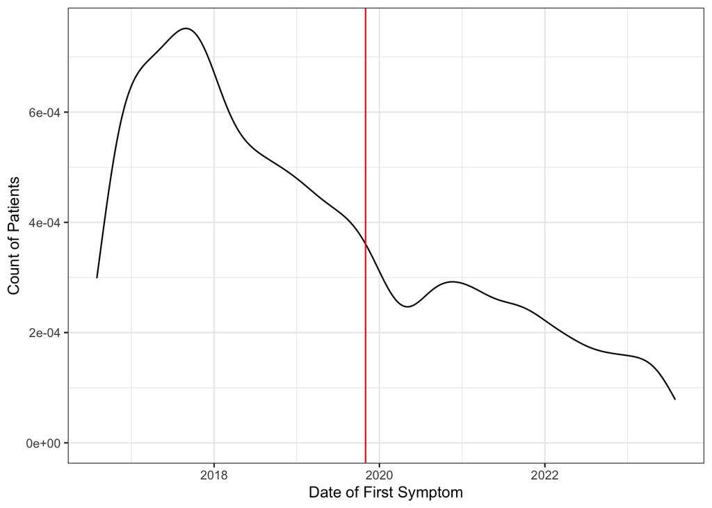

```r
ch2_final %>%
  filter(never_dx=='Never Dx') %>%
  ggplot(aes(x=as.Date(first_symptom_date)), data=.) +
  geom_density() +
  geom_vline(xintercept = as.Date('2019-11-01'), color='red') +
  ylab('Count of Patients') +
  xlab('Date of First Symptom') +
  theme_bw()
```

The red line indicates the mean time to diagnosis for cases. Therefore, if we hypothesize that most of these patients are true cases who have yet to be diagnosed we might expect them to on average have a first symptom on or after the date of the red line.

### Censoring over time

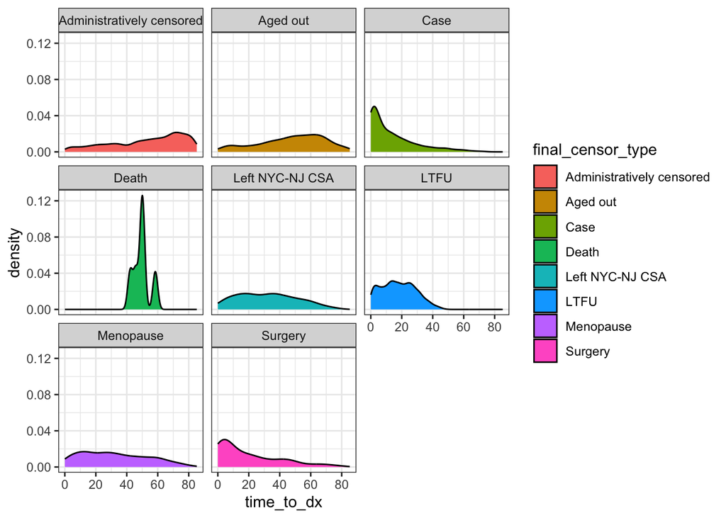

```r
ch2_final %>%
  mutate(final_censor_type = ifelse(is.na(final_censor_type), 'Administratively censored',
                                    final_censor_type)) %>%
  ggplot(aes(x=time_to_dx, fill = final_censor_type), data=.) +
  geom_density() +
  facet_wrap(~final_censor_type) +
  theme_bw()
```

```r
# look at death dates since there is a weird spike
#sort(ch2_final$final_censor_date[which(ch2_final$final_censor_type == 'Death')])
# they appear to span COVID and onward (potentially COVID related/as participants aged)
```